# Sample Integration of

**Find differentially expression genes/features for each cluster**

```r
ovary_merged.markers <- FindAllMarkers(ovary_merged, only.pos = TRUE, min.pct = 0.25, logfc.threshold = .5)
```

[output not shown]

```r
top_cmarker_gene <- ovary_merged.markers %>% group_by(cluster) %>% slice_max(n = 1, order_by = avg_log2FC)
```

Based on the FeaturePlot, most of the top cluster marker genes do not seem to be matching the regions corresponding to their clusters with the exception of the clusters 4-8. Looking back at the first 2 plots showing the UMAP, it could potentially be that clusters 4-8 are mostly coming from the same donor.

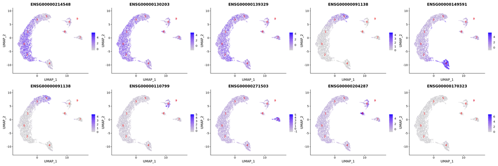

```r
options(repr.plot.width = 30, repr.plot.height = 10)
FeaturePlot(ovary_merged, features = top_cmarker_gene$gene, label=T, label.color='red', ncol=5)
```

VlnPlot offers a better view of the expression levels of the genes within Seurat clusters. Specifically, DoHeatmap may indicate that better separation observed in 4-8 could potentially be due to a lower number of cell memberships that would allow the clusters to be more homogeneous.

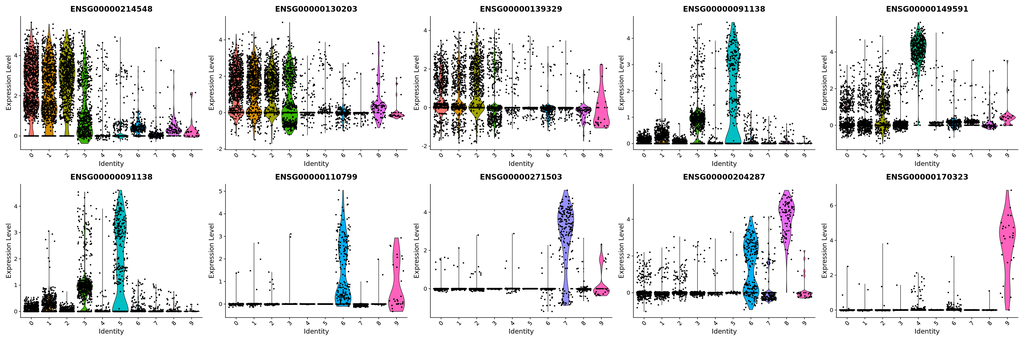

```r
options(repr.plot.width = 30, repr.plot.height = 10)
VlnPlot(ovary_merged, features = top_cmarker_gene$gene, ncol=5)
```

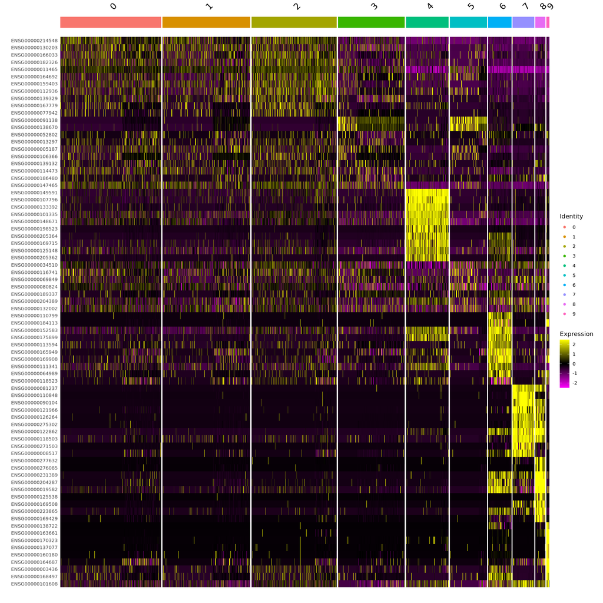

```r
options(repr.plot.width = 15, repr.plot.height = 15)
top10 <- ovary_merged.markers %>% group_by(cluster) %>% top_n(n = 10, wt = avg_log2FC)
DoHeatmap(ovary_merged, features = top10$gene)
```

```r
#total count for each cluster_id across the entire dataset
cluster_totals <- ovary_merged@meta.data %>% count(seurat_clusters) %>% rename(total_by_cluster = n)

donor_totals <- ovary_merged@meta.data %>% count(donor_id, seurat_clusters) %>%
  group_by(donor_id) %>% mutate(total_by_donor = sum(n), freq_by_donor = n / total_by_donor) %>%
  ungroup()

left_join(donor_totals, cluster_totals, by = "seurat_clusters") %>%
  mutate(freq_by_cluster = n / total_by_cluster) %>%
  group_by(donor_id) %>%
  arrange(donor_id, desc(freq_by_donor)) %>% slice(1) %>%
  ungroup()
```

A tibble: 11 × 7

| donor_id <chr> | seurat_clusters <fct> | n <int> | total_by_donor <int> | freq_by_donor <dbl> | total_by_cluster <int> | freq_by_cluster <dbl> |
| --- | --- | --- | --- | --- | --- | --- |
| D1_3041 | 5 | 160 | 182 | 0.8791209 | 364 | 0.43956044 |
| D2_3061 | 5 | 115 | 222 | 0.5180180 | 364 | 0.31593407 |
| D3_3203 | 0 | 249 | 717 | 0.3472803 | 989 | 0.25176946 |
| D5_3296 | 0 | 171 | 473 | 0.3615222 | 989 | 0.17290192 |
| D7_3391 | 2 | 231 | 467 | 0.4946467 | 835 | 0.27664671 |
| D8_3453 | 4 | 181 | 552 | 0.3278986 | 416 | 0.43509615 |
| pat0 | 0 | 21 | 77 | 0.2727273 | 989 | 0.02123357 |
| pat2 | 3 | 235 | 290 | 0.8103448 | 654 | 0.35932722 |
| pat3 | 3 | 197 | 600 | 0.3283333 | 654 | 0.30122324 |
| pat7 | 0 | 270 | 738 | 0.3658537 | 989 | 0.27300303 |
| pat9 | 6 | 89 | 363 | 0.2451791 | 228 | 0.39035088 |

From the table above, and as well as the previos plots, it's hard to tell exactly why 4-8 is showing the most clear separation in terms of the top marker gene. Given that these results are generated using only 10% coming from each study, this likely will change if it is run again on the entire dataset.